# Petiole and Leaf Area to LMA

## Data Prep

Loading require packages

```r
require(BIEN)
require(plyr)
require(tidyr)
require(dplyr)
```

```r
require(mosaic)
require(stringr)
require(lme4)
require(magrittr)
```

First, we need to fix the fossil data necessary for prediction. Fossil data is compared to living data in order to come to conclusions when identifying the families of found fossils based off of LMA. The data has previously been adjusted to fix misspelled names, combine observations, and organize all of the information.

```r
florissant_fossil_int <- readRDS("../data/processed/04_florissant_fossil_clean.rds")
renova_fossil_int <- readRDS("../data/processed/04_renova_fossil_clean.rds")
bridgecreek_fossil_int <- readRDS("../data/processed/04_bridgecreek_fossil_clean.rds")

fossil_comb <- rbind(florissant_fossil_int,renova_fossil_int,bridgecreek_fossil_int)
fossil_gen <- fossil_comb$Genus
fossil_gen <- unique(fossil_gen)
fossil_gen_df <- as.data.frame(fossil_gen)
fossil_tax <- BIEN_taxonomy_genus(fossil_gen)
fossil_tax <- fossil_tax[-c(1,7:9)]
fossil_tax <- unique(fossil_tax)

all_fossil <- rbind(florissant_fossil_int, renova_fossil_int, bridgecreek_fossil_int)
all_fossil$binomial <- paste(all_fossil$Genus, all_fossil$species)
all_fossil$binomial <- str_replace_all(all_fossil$binomial,"\\s+","_")
all_fossil <- all_fossil[-c(1,2)]
```

```r
 all_fossil_LMEpred <- all_fossil %>%
  separate(binomial,
    c("scrubbed_genus", "species"))
all_fossil_royer_pred <- left_join(all_fossil_LMEpred, fossil_tax, by = "scrubbed_genus")

all_fossil_royer_pred <- na.omit(all_fossil_royer_pred)
all_fossil_royer_pred <- unique(all_fossil_royer_pred)

colnames(all_fossil)[colnames(all_fossil)=="Petiole Width (cm)"] <- "avg_petiole_width"
colnames(all_fossil)[colnames(all_fossil)=="Leaf Area (cm^2)"] <- "avg_LA"
colnames(all_fossil)[colnames(all_fossil)=="PW^2/A"] <- "log_pet_leafarea"
colnames(all_fossil)[colnames(all_fossil)=="LMA (g/m^2)"] <- "log_LMA"
```

We first get rid of observations containing “na”. Then, we create a leaf mass prediction and model using family as a factor.

```r
royer_tax_full <- readRDS("../data/processed/07_lm4_royer")
royer_tax_na_omit<-na.omit(royer_tax_full)

### Omitting "Unknown" from the family column
royer_tax_full$scrubbed_family[royer_tax_full$scrubbed_family=="Unknown"] <- ""

###Creating leaf mass prediction model
royer_lme <- lmer(log_lma~log_pet_leafarea + (1|order/scrubbed_family/scrubbed_genus), data=royer_tax_full)


royer_lme_sum<- summary(royer_lme)
royer_lme_sum
```

```
## Linear mixed model fit by REML ['lmerMod']
## Formula:
## log_lma ~ log_pet_leafarea + (1 | order/scrubbed_family/scrubbed_genus)
##    Data: royer_tax_full
##
## REML criterion at convergence: 482.5
##
## Scaled residuals:
##      Min       1Q   Median       3Q      Max
## -2.42519 -0.53771  0.02876  0.57631  2.86066
##
## Random effects:
##  Groups                                 Name        Variance Std.Dev.
##  scrubbed_genus:(scrubbed_family:order) (Intercept) 0.058435 0.24173
##  scrubbed_family:order                  (Intercept) 0.009571 0.09783
##  order                                  (Intercept) 0.018794 0.13709
##  Residual                                           0.092357 0.30390
## Number of obs: 527, groups:
## scrubbed_genus:(scrubbed_family:order), 292; scrubbed_family:order, 105; order, 34
##
## Fixed effects:
##                  Estimate Std. Error t value
## (Intercept)       6.74202    0.11921   56.55
## log_pet_leafarea  0.33856    0.01676   20.20
##
## Correlation of Fixed Effects:
##             (Intr)
## log_pet_lfr 0.948
```

We use pattern matching and replacement to use the lm predictions and models using family as a factor.

```r
royer_fossil_dropped <-   all_fossil_royer_pred %>%
  filter(!grepl('Cercidiphyllaceae', scrubbed_family)) %>%
  filter(!grepl('Smilacaceae', scrubbed_family)) %>%
  filter(!grepl('Staphyleaceae', scrubbed_family))
```

This code fixes royer_tax_full.

```r
royer_tax_fam_count <- royer_tax_full%>%
  group_by(scrubbed_family) %>%
  tally() %>%
  filter(!grepl('Unknown', scrubbed_family))

royer_tax_count <- left_join(royer_tax_full, royer_tax_fam_count, by="scrubbed_family")
```

### Mixed Effects Modeling

Determining the top 5 extant families with the most samples, and the top 10 families respectively.

```r
royer_tax_top5 <- subset(royer_tax_count, as.numeric(n)>23)
royer_tax_over10 <- subset(royer_tax_count, as.numeric(n)>9)
```

```r
royer_lmfam_top5 <- lm(log_lma~log_pet_leafarea, data = royer_tax_top5)
pred_lmfam_top5 <-  as.data.frame(predict(royer_lmfam_top5, interval="prediction"))
royer_lmfam_top5_bound <-  cbind(royer_tax_top5, pred_lmfam_top5)
```

Plotting log_lma vs log(petiole^2/leafarea) for the top 5 families.

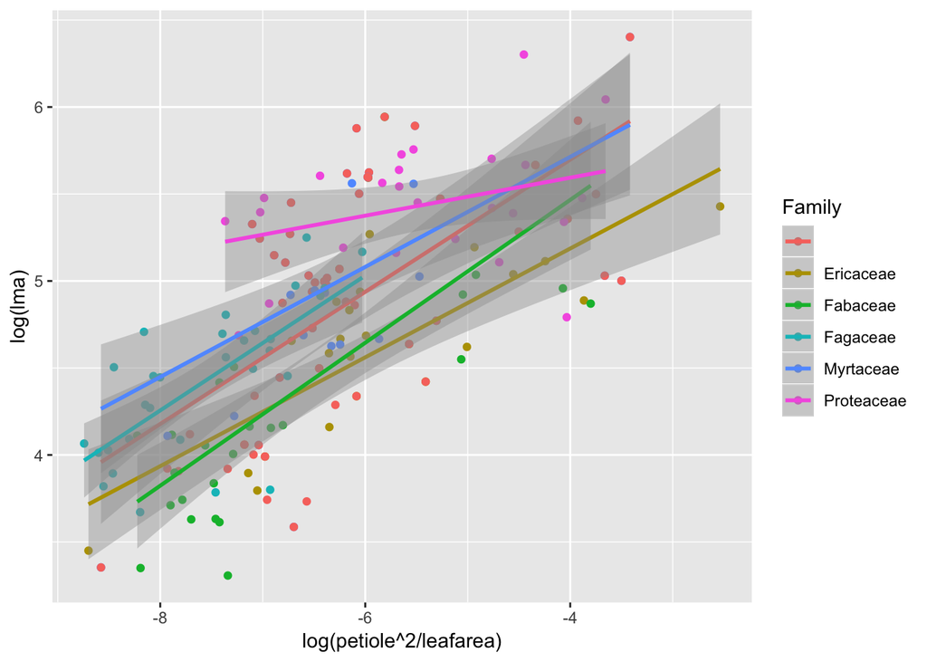

```r
ggplot(royer_lmfam_top5_bound, aes(log_pet_leafarea, log_lma))+
  aes(color=royer_lmfam_top5_bound$scrubbed_family)+
  geom_point() +
  geom_smooth(method=lm, se=TRUE)+
  labs(x="log(petiole^2/leafarea)")+
  labs(y="log(lma)")+
  labs(color = "Family")
```

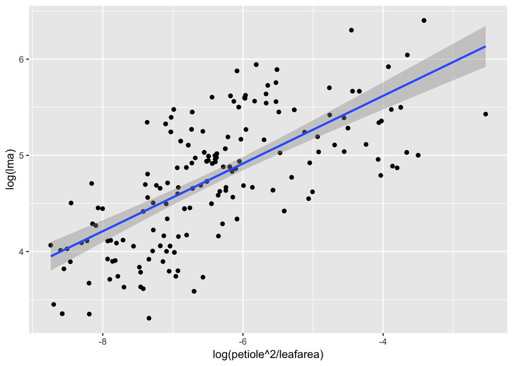

```r
ggplot(royer_lmfam_top5_bound, aes(log_pet_leafarea, log_lma))+
  geom_point() +
  geom_smooth(method=lm, se=TRUE)+
  labs(x="log(petiole^2/leafarea)")+
  labs(y="log(lma)")+
  labs(color = "Family")
```